# **Toronto Crime Predictions**

back to the top

## **Introduction**

|  | geometry | _id | AREA_ID | AREA_ATTR_ID | PARENT_AREA_ID | AREA_SHORT_CODE | AREA_LONG_CODE | AREA_NAME | AREA_DESC | CLASSIFICATION | CLASSIFICATION_CODE | OBJECTID |
| --- | --- | --- | --- | --- | --- | --- | --- | --- | --- | --- | --- | --- |
| 0 | MULTIPOLYGON (((-79.38635 43.69783, -79.38623 ... | 1 | 2502366 | 26022881 | 0 | 174 | 174 | South Eglinton-Davisville | South Eglinton-Davisville (174) | Not an NIA or Emerging Neighbourhood | NA | 17824737.0 |
| 1 | MULTIPOLYGON (((-79.39744 43.70693, -79.39837 ... | 2 | 2502365 | 26022880 | 0 | 173 | 173 | North Toronto | North Toronto (173) | Not an NIA or Emerging Neighbourhood | NA | 17824753.0 |
| 2 | MULTIPOLYGON (((-79.43411 43.66015, -79.43537 ... | 3 | 2502364 | 26022879 | 0 | 172 | 172 | Dovercourt Village | Dovercourt Village (172) | Not an NIA or Emerging Neighbourhood | NA | 17824769.0 |
| 3 | MULTIPOLYGON (((-79.4387 43.66766, -79.43841 4... | 4 | 2502363 | 26022878 | 0 | 171 | 171 | Junction-Wallace Emerson | Junction-Wallace Emerson (171) | Not an NIA or Emerging Neighbourhood | NA | 17824785.0 |
| 4 | MULTIPOLYGON (((-79.38404 43.64497, -79.38502 ... | 5 | 2502362 | 26022877 | 0 | 170 | 170 | Yonge-Bay Corridor | Yonge-Bay Corridor (170) | Not an NIA or Emerging Neighbourhood | NA | 17824801.0 |

back to the top

|  | geometry | NEIGHBOURHOOD_158 |
| --- | --- | --- |
| 0 | MULTIPOLYGON (((-79.38635 43.69783, -79.38623 ... | South Eglinton-Davisville (174) |
| 1 | MULTIPOLYGON (((-79.39744 43.70693, -79.39837 ... | North Toronto (173) |
| 2 | MULTIPOLYGON (((-79.43411 43.66015, -79.43537 ... | Dovercourt Village (172) |
| 3 | MULTIPOLYGON (((-79.4387 43.66766, -79.43841 4... | Junction-Wallace Emerson (171) |
| 4 | MULTIPOLYGON (((-79.38404 43.64497, -79.38502 ... | Yonge-Bay Corridor (170) |

back to the top

|  | geometry | NEIGHBOURHOOD_158 | HOOD_158 |
| --- | --- | --- | --- |
| 0 | MULTIPOLYGON (((-79.38635 43.69783, -79.38623 ... | South Eglinton-Davisville (174) | 174 |
| 1 | MULTIPOLYGON (((-79.39744 43.70693, -79.39837 ... | North Toronto (173) | 173 |
| 2 | MULTIPOLYGON (((-79.43411 43.66015, -79.43537 ... | Dovercourt Village (172) | 172 |
| 3 | MULTIPOLYGON (((-79.4387 43.66766, -79.43841 4... | Junction-Wallace Emerson (171) | 171 |
| 4 | MULTIPOLYGON (((-79.38404 43.64497, -79.38502 ... | Yonge-Bay Corridor (170) | 170 |

back to the top

[interactive chart not shown]

back to the top

## **Retrieve Data from API**

back to the top

back to the top

[output not shown]

[output cut: 108 more lines]

[output not shown]

back to the top

[output not shown]

[output cut: 90 more lines]

[output not shown]

back to the top

```
(   OBJECTID EVENT_UNIQUE_ID    REPORT_DATE       OCC_DATE  REPORT_YEAR  \
 0    246675     GO-20213605  1609477200000  1609477200000         2021
 1    246676     GO-20213400  1609477200000  1609477200000         2021
 2    246677     GO-20211123  1609477200000  1609477200000         2021
 3    246678      GO-2021445  1609477200000  1609477200000         2021
 4    246679     GO-20213400  1609477200000  1609477200000         2021

   REPORT_MONTH  REPORT_DAY  REPORT_DOY  REPORT_DOW  REPORT_HOUR  ...  \
 0      January           1           1  Friday               16  ...
 1      January           1           1  Friday               16  ...
 2      January           1           1  Friday                7  ...
 3      January           1           1  Friday                1  ...
 4      January           1           1  Friday               16  ...

    UCR_CODE UCR_EXT                 OFFENCE  MCI_CATEGORY HOOD_158  \
```

[output cut: 22 more lines]

back to the top

## **Preprocess the Data**

back to the top

```
Index(['OBJECTID', 'EVENT_UNIQUE_ID', 'REPORT_DATE', 'OCC_DATE', 'REPORT_YEAR',
       'REPORT_MONTH', 'REPORT_DAY', 'REPORT_DOY', 'REPORT_DOW', 'REPORT_HOUR',
       'OCC_YEAR', 'OCC_MONTH', 'OCC_DAY', 'OCC_DOY', 'OCC_DOW', 'OCC_HOUR',
       'DIVISION', 'LOCATION_TYPE', 'PREMISES_TYPE', 'UCR_CODE', 'UCR_EXT',
       'OFFENCE', 'MCI_CATEGORY', 'HOOD_158', 'NEIGHBOURHOOD_158', 'HOOD_140',
       'NEIGHBOURHOOD_140', 'LONG_WGS84', 'LAT_WGS84'],
      dtype='object')
```

back to the top

|  | OBJECTID | EVENT_UNIQUE_ID | REPORT_DATE | OCC_DATE | REPORT_YEAR | REPORT_MONTH | REPORT_DAY | REPORT_DOY | REPORT_DOW | REPORT_HOUR | ... | UCR_CODE | UCR_EXT | OFFENCE | MCI_CATEGORY | HOOD_158 | NEIGHBOURHOOD_158 | HOOD_140 | NEIGHBOURHOOD_140 | LONG_WGS84 | LAT_WGS84 |
| --- | --- | --- | --- | --- | --- | --- | --- | --- | --- | --- | --- | --- | --- | --- | --- | --- | --- | --- | --- | --- | --- |
| 0 | 246675 | GO-20213605 | 1609477200000 | 1609477200000 | 2021 | January | 1 | 1 | Friday | 16 | ... | 2135 | 210 | Theft Of Motor Vehicle | Auto Theft | 94 | Wychwood (94) | 094 | Wychwood (94) | -79.425762 | 43.681769 |
| 1 | 246676 | GO-20213400 | 1609477200000 | 1609477200000 | 2021 | January | 1 | 1 | Friday | 16 | ... | 2135 | 210 | Theft Of Motor Vehicle | Auto Theft | 0 | NSA | NSA | NSA | 0.000000 | 0.000000 |
| 2 | 246677 | GO-20211123 | 1609477200000 | 1609477200000 | 2021 | January | 1 | 1 | Friday | 7 | ... | 2135 | 210 | Theft Of Motor Vehicle | Auto Theft | 31 | Yorkdale-Glen Park (31) | 031 | Yorkdale-Glen Park (31) | -79.460110 | 43.721013 |
| 3 | 246678 | GO-2021445 | 1609477200000 | 1609477200000 | 2021 | January | 1 | 1 | Friday | 1 | ... | 2135 | 210 | Theft Of Motor Vehicle | Auto Theft | 151 | Yonge-Doris (151) | 051 | Willowdale East (51) | -79.415293 | 43.778743 |
| 4 | 246679 | GO-20213400 | 1609477200000 | 1609477200000 | 2021 | January | 1 | 1 | Friday | 16 | ... | 2135 | 210 | Theft Of Motor Vehicle | Auto Theft | 0 | NSA | NSA | NSA | 0.000000 | 0.000000 |
| ... | ... | ... | ... | ... | ... | ... | ... | ... | ... | ... | ... | ... | ... | ... | ... | ... | ... | ... | ... | ... | ... |
| 147546 | 396731 | GO-20241427047 | 1719723600000 | 1719637200000 | 2024 | June | 30 | 182 | Sunday | 16 | ... | 1430 | 100 | Assault | Assault | 71 | Cabbagetown-South St.James Town (71) | 071 | Cabbagetown-South St.James Town (71) | -79.373043 | 43.663195 |
| 147547 | 396732 | GO-20241427869 | 1719723600000 | 1719723600000 | 2024 | June | 30 | 182 | Sunday | 18 | ... | 2133 | 200 | Theft Over - Shoplifting | Theft Over | 27 | York University Heights (27) | 027 | York University Heights (27) | -79.464942 | 43.759469 |
| 147548 | 396733 | GO-20241423116 | 1719723600000 | 1719637200000 | 2024 | June | 30 | 182 | Sunday | 2 | ... | 1450 | 120 | Discharge Firearm With Intent | Assault | 144 | Morningside Heights (144) | 131 | Rouge (131) | -79.248477 | 43.837237 |
| 147549 | 396734 | GO-20241426669 | 1719723600000 | 1718859600000 | 2024 | June | 30 | 182 | Sunday | 15 | ... | 2132 | 200 | Theft From Motor Vehicle Over | Theft Over | 160 | Mimico-Queensway (160) | 017 | Mimico (includes Humber Bay Shores) (17) | -79.521053 | 43.616490 |
| 147550 | 396735 | GO-20241425318 | 1719723600000 | 1719637200000 | 2024 | June | 30 | 182 | Sunday | 11 | ... | 1430 | 100 | Assault | Assault | 18 | New Toronto (18) | 018 | New Toronto (18) | -79.513940 | 43.598831 |

147551 rows × 29 columns

back to the top

|  | OCC_MONTH |
| --- | --- |
| 0 | January |
| 1 | January |
| 2 | January |
| 3 | January |
| 4 | January |
| ... | ... |
| 147546 | June |
| 147547 | June |
| 147548 | June |
| 147549 | June |
| 147550 | June |

147551 rows × 1 columns

**dtype:** object

back to the top

|  | OCC_MONTH |
| --- | --- |
| 0 | 1 |
| 1 | 1 |
| 2 | 1 |
| 3 | 1 |
| 4 | 1 |
| ... | ... |
| 147546 | 6 |
| 147547 | 6 |
| 147548 | 6 |
| 147549 | 6 |
| 147550 | 6 |

147551 rows × 1 columns

**dtype:** int64

back to the top

|  | EVENT_UNIQUE_ID | NEIGHBOURHOOD_158 | HOOD_158 | LAT_WGS84 | LONG_WGS84 | PREMISES_TYPE | OCC_DATE | OCC_YEAR | OCC_MONTH | OCC_DAY | OCC_HOUR | MCI_CATEGORY |
| --- | --- | --- | --- | --- | --- | --- | --- | --- | --- | --- | --- | --- |
| 0 | GO-20213605 | Wychwood (94) | 94 | 43.681769 | -79.425762 | Outside | 1609477200000 | 2021 | 1 | 1 | 16 | Auto Theft |
| 1 | GO-20213400 | NSA | 0 | 0.000000 | 0.000000 | Commercial | 1609477200000 | 2021 | 1 | 1 | 4 | Auto Theft |
| 2 | GO-20211123 | Yorkdale-Glen Park (31) | 31 | 43.721013 | -79.460110 | Other | 1609477200000 | 2021 | 1 | 1 | 4 | Auto Theft |
| 3 | GO-2021445 | Yonge-Doris (151) | 151 | 43.778743 | -79.415293 | Other | 1609477200000 | 2021 | 1 | 1 | 1 | Auto Theft |
| 4 | GO-20213400 | NSA | 0 | 0.000000 | 0.000000 | Commercial | 1609477200000 | 2021 | 1 | 1 | 4 | Auto Theft |
| ... | ... | ... | ... | ... | ... | ... | ... | ... | ... | ... | ... | ... |
| 147546 | GO-20241427047 | Cabbagetown-South St.James Town (71) | 71 | 43.663195 | -79.373043 | Apartment | 1719637200000 | 2024 | 6 | 29 | 23 | Assault |
| 147547 | GO-20241427869 | York University Heights (27) | 27 | 43.759469 | -79.464942 | Commercial | 1719723600000 | 2024 | 6 | 30 | 18 | Theft Over |
| 147548 | GO-20241423116 | Morningside Heights (144) | 144 | 43.837237 | -79.248477 | Outside | 1719637200000 | 2024 | 6 | 29 | 21 | Assault |
| 147549 | GO-20241426669 | Mimico-Queensway (160) | 160 | 43.616490 | -79.521053 | Outside | 1718859600000 | 2024 | 6 | 20 | 13 | Theft Over |
| 147550 | GO-20241425318 | New Toronto (18) | 18 | 43.598831 | -79.513940 | House | 1719637200000 | 2024 | 6 | 29 | 20 | Assault |

147551 rows × 12 columns

back to the top

|  | Assault | Auto Theft | Break and Enter | Robbery | Theft Over |
| --- | --- | --- | --- | --- | --- |
| 0 | 0 | 1 | 0 | 0 | 0 |
| 1 | 0 | 1 | 0 | 0 | 0 |
| 2 | 0 | 1 | 0 | 0 | 0 |
| 3 | 0 | 1 | 0 | 0 | 0 |
| 4 | 0 | 1 | 0 | 0 | 0 |
| ... | ... | ... | ... | ... | ... |
| 147546 | 1 | 0 | 0 | 0 | 0 |
| 147547 | 0 | 0 | 0 | 0 | 1 |
| 147548 | 1 | 0 | 0 | 0 | 0 |
| 147549 | 0 | 0 | 0 | 0 | 1 |
| 147550 | 1 | 0 | 0 | 0 | 0 |

147551 rows × 5 columns

back to the top

|  | EVENT_UNIQUE_ID | NEIGHBOURHOOD_158 | HOOD_158 | LAT_WGS84 | LONG_WGS84 | PREMISES_TYPE | OCC_DATE | OCC_YEAR | OCC_MONTH | OCC_DAY | OCC_HOUR | Assault | Auto Theft | Break and Enter | Robbery | Theft Over |
| --- | --- | --- | --- | --- | --- | --- | --- | --- | --- | --- | --- | --- | --- | --- | --- | --- |
| 0 | GO-20213605 | Wychwood (94) | 94 | 43.681769 | -79.425762 | Outside | 1609477200000 | 2021 | 1 | 1 | 16 | 0 | 1 | 0 | 0 | 0 |
| 1 | GO-20213400 | NSA | 0 | 0.000000 | 0.000000 | Commercial | 1609477200000 | 2021 | 1 | 1 | 4 | 0 | 1 | 0 | 0 | 0 |
| 2 | GO-20211123 | Yorkdale-Glen Park (31) | 31 | 43.721013 | -79.460110 | Other | 1609477200000 | 2021 | 1 | 1 | 4 | 0 | 1 | 0 | 0 | 0 |
| 3 | GO-2021445 | Yonge-Doris (151) | 151 | 43.778743 | -79.415293 | Other | 1609477200000 | 2021 | 1 | 1 | 1 | 0 | 1 | 0 | 0 | 0 |
| 4 | GO-20213400 | NSA | 0 | 0.000000 | 0.000000 | Commercial | 1609477200000 | 2021 | 1 | 1 | 4 | 0 | 1 | 0 | 0 | 0 |
| ... | ... | ... | ... | ... | ... | ... | ... | ... | ... | ... | ... | ... | ... | ... | ... | ... |
| 147546 | GO-20241427047 | Cabbagetown-South St.James Town (71) | 71 | 43.663195 | -79.373043 | Apartment | 1719637200000 | 2024 | 6 | 29 | 23 | 1 | 0 | 0 | 0 | 0 |
| 147547 | GO-20241427869 | York University Heights (27) | 27 | 43.759469 | -79.464942 | Commercial | 1719723600000 | 2024 | 6 | 30 | 18 | 0 | 0 | 0 | 0 | 1 |
| 147548 | GO-20241423116 | Morningside Heights (144) | 144 | 43.837237 | -79.248477 | Outside | 1719637200000 | 2024 | 6 | 29 | 21 | 1 | 0 | 0 | 0 | 0 |
| 147549 | GO-20241426669 | Mimico-Queensway (160) | 160 | 43.616490 | -79.521053 | Outside | 1718859600000 | 2024 | 6 | 20 | 13 | 0 | 0 | 0 | 0 | 1 |
| 147550 | GO-20241425318 | New Toronto (18) | 18 | 43.598831 | -79.513940 | House | 1719637200000 | 2024 | 6 | 29 | 20 | 1 | 0 | 0 | 0 | 0 |

147551 rows × 16 columns

back to the top

| EVENT_UNIQUE_ID | NEIGHBOURHOOD_158 | HOOD_158 | LAT_WGS84 | LONG_WGS84 | PREMISES_TYPE | OCC_DATE | OCC_YEAR | OCC_MONTH | OCC_DAY | OCC_HOUR |
| --- | --- | --- | --- | --- | --- | --- | --- | --- | --- | --- |
| GO-20211000033 | West Queen West (162) | 162 | 43.646286 | -79.408568 | Commercial | 1622264400000 | 2021 | 5 | 29 | 21 |
| GO-2021100004 | Morningside Heights (144) | 144 | 43.807252 | -79.162903 | Outside | 1610773200000 | 2021 | 1 | 16 | 17 |
| GO-20211000054 | Moss Park (73) | 73 | 43.657067 | -79.374531 | Apartment | 1622264400000 | 2021 | 5 | 29 | 22 |
| GO-20211000193 | Fort York-Liberty Village (163) | 163 | 43.636618 | -79.399704 | Apartment | 1622264400000 | 2021 | 5 | 29 | 23 |
| GO-20211000248 | Eglinton East (138) | 138 | 43.737099 | -79.246230 | Outside | 1622264400000 | 2021 | 5 | 29 | 21 |
| ... | ... | ... | ... | ... | ... | ... | ... | ... | ... | ... |
| GO-20249997 | Junction-Wallace Emerson (171) | 171 | 43.668917 | -79.442637 | Outside | 1704085200000 | 2024 | 1 | 1 | 18 |
| GO-202499972 | Edenbridge-Humber Valley (9) | 9 | 43.672705 | -79.522472 | House | 1705208400000 | 2024 | 1 | 14 | 3 |
| GO-2024999786 | Flemingdon Park (44) | 44 | 43.718727 | -79.334948 | Apartment | 1714539600000 | 2024 | 5 | 1 | 0 |
| GO-2024999795 | Oakridge (121) | 121 | 43.691225 | -79.288346 | Commercial | 1715230800000 | 2024 | 5 | 9 | 13 |
| GO-2024999882 | Eglinton East (138) | 138 | 43.738856 | -79.238421 | Commercial | 1715230800000 | 2024 | 5 | 9 | 14 |

129217 rows × 10 columns

back to the top

| EVENT_UNIQUE_ID | Assault | Auto Theft | Break and Enter | Robbery | Theft Over |
| --- | --- | --- | --- | --- | --- |
| GO-20211000033 | 0 | 0 | 1 | 0 | 0 |
| GO-2021100004 | 0 | 1 | 0 | 0 | 0 |
| GO-20211000054 | 1 | 0 | 0 | 0 | 0 |
| GO-20211000193 | 1 | 0 | 0 | 0 | 0 |
| GO-20211000248 | 1 | 0 | 0 | 0 | 0 |
| ... | ... | ... | ... | ... | ... |
| GO-20249997 | 0 | 1 | 0 | 0 | 0 |
| GO-202499972 | 0 | 1 | 0 | 0 | 0 |
| GO-2024999786 | 1 | 0 | 0 | 0 | 0 |
| GO-2024999795 | 1 | 0 | 0 | 0 | 0 |
| GO-2024999882 | 1 | 0 | 0 | 0 | 0 |

129217 rows × 5 columns

back to the top

|  | EVENT_UNIQUE_ID | NEIGHBOURHOOD_158 | HOOD_158 | LAT_WGS84 | LONG_WGS84 | PREMISES_TYPE | OCC_DATE | OCC_YEAR | OCC_MONTH | OCC_DAY | OCC_HOUR | Assault | Auto Theft | Break and Enter | Robbery | Theft Over |
| --- | --- | --- | --- | --- | --- | --- | --- | --- | --- | --- | --- | --- | --- | --- | --- | --- |
| 0 | GO-20211000033 | West Queen West (162) | 162 | 43.646286 | -79.408568 | Commercial | 1622264400000 | 2021 | 5 | 29 | 21 | 0 | 0 | 1 | 0 | 0 |
| 1 | GO-2021100004 | Morningside Heights (144) | 144 | 43.807252 | -79.162903 | Outside | 1610773200000 | 2021 | 1 | 16 | 17 | 0 | 1 | 0 | 0 | 0 |
| 2 | GO-20211000054 | Moss Park (73) | 73 | 43.657067 | -79.374531 | Apartment | 1622264400000 | 2021 | 5 | 29 | 22 | 1 | 0 | 0 | 0 | 0 |
| 3 | GO-20211000193 | Fort York-Liberty Village (163) | 163 | 43.636618 | -79.399704 | Apartment | 1622264400000 | 2021 | 5 | 29 | 23 | 1 | 0 | 0 | 0 | 0 |
| 4 | GO-20211000248 | Eglinton East (138) | 138 | 43.737099 | -79.246230 | Outside | 1622264400000 | 2021 | 5 | 29 | 21 | 1 | 0 | 0 | 0 | 0 |
| ... | ... | ... | ... | ... | ... | ... | ... | ... | ... | ... | ... | ... | ... | ... | ... | ... |
| 129212 | GO-20249997 | Junction-Wallace Emerson (171) | 171 | 43.668917 | -79.442637 | Outside | 1704085200000 | 2024 | 1 | 1 | 18 | 0 | 1 | 0 | 0 | 0 |
| 129213 | GO-202499972 | Edenbridge-Humber Valley (9) | 9 | 43.672705 | -79.522472 | House | 1705208400000 | 2024 | 1 | 14 | 3 | 0 | 1 | 0 | 0 | 0 |
| 129214 | GO-2024999786 | Flemingdon Park (44) | 44 | 43.718727 | -79.334948 | Apartment | 1714539600000 | 2024 | 5 | 1 | 0 | 1 | 0 | 0 | 0 | 0 |
| 129215 | GO-2024999795 | Oakridge (121) | 121 | 43.691225 | -79.288346 | Commercial | 1715230800000 | 2024 | 5 | 9 | 13 | 1 | 0 | 0 | 0 | 0 |
| 129216 | GO-2024999882 | Eglinton East (138) | 138 | 43.738856 | -79.238421 | Commercial | 1715230800000 | 2024 | 5 | 9 | 14 | 1 | 0 | 0 | 0 | 0 |

129217 rows × 16 columns

## **Create the Model**

### Creating the Testing and Training Datasets - First Approach

back to the top

|  | EVENT_UNIQUE_ID | NEIGHBOURHOOD_158 | HOOD_158 | LAT_WGS84 | LONG_WGS84 | PREMISES_TYPE | OCC_DATE | OCC_YEAR | OCC_MONTH | OCC_DAY | OCC_HOUR | Assault | Auto Theft | Break and Enter | Robbery | Theft Over | Total_Count |
| --- | --- | --- | --- | --- | --- | --- | --- | --- | --- | --- | --- | --- | --- | --- | --- | --- | --- |
| 0 | GO-20211000033 | West Queen West (162) | 162 | 43.646286 | -79.408568 | Commercial | 1622264400000 | 2021 | 5 | 29 | 21 | 0 | 0 | 1 | 0 | 0 | 1 |
| 1 | GO-2021100004 | Morningside Heights (144) | 144 | 43.807252 | -79.162903 | Outside | 1610773200000 | 2021 | 1 | 16 | 17 | 0 | 1 | 0 | 0 | 0 | 1 |
| 2 | GO-20211000054 | Moss Park (73) | 73 | 43.657067 | -79.374531 | Apartment | 1622264400000 | 2021 | 5 | 29 | 22 | 1 | 0 | 0 | 0 | 0 | 1 |
| 3 | GO-20211000193 | Fort York-Liberty Village (163) | 163 | 43.636618 | -79.399704 | Apartment | 1622264400000 | 2021 | 5 | 29 | 23 | 1 | 0 | 0 | 0 | 0 | 1 |
| 4 | GO-20211000248 | Eglinton East (138) | 138 | 43.737099 | -79.246230 | Outside | 1622264400000 | 2021 | 5 | 29 | 21 | 1 | 0 | 0 | 0 | 0 | 1 |
| ... | ... | ... | ... | ... | ... | ... | ... | ... | ... | ... | ... | ... | ... | ... | ... | ... | ... |
| 129212 | GO-20249997 | Junction-Wallace Emerson (171) | 171 | 43.668917 | -79.442637 | Outside | 1704085200000 | 2024 | 1 | 1 | 18 | 0 | 1 | 0 | 0 | 0 | 1 |
| 129213 | GO-202499972 | Edenbridge-Humber Valley (9) | 9 | 43.672705 | -79.522472 | House | 1705208400000 | 2024 | 1 | 14 | 3 | 0 | 1 | 0 | 0 | 0 | 1 |
| 129214 | GO-2024999786 | Flemingdon Park (44) | 44 | 43.718727 | -79.334948 | Apartment | 1714539600000 | 2024 | 5 | 1 | 0 | 1 | 0 | 0 | 0 | 0 | 1 |
| 129215 | GO-2024999795 | Oakridge (121) | 121 | 43.691225 | -79.288346 | Commercial | 1715230800000 | 2024 | 5 | 9 | 13 | 1 | 0 | 0 | 0 | 0 | 1 |
| 129216 | GO-2024999882 | Eglinton East (138) | 138 | 43.738856 | -79.238421 | Commercial | 1715230800000 | 2024 | 5 | 9 | 14 | 1 | 0 | 0 | 0 | 0 | 1 |

129217 rows × 17 columns

back to the top

|  | HOOD_158 | OCC_YEAR | OCC_MONTH | Total_Count |
| --- | --- | --- | --- | --- |
| 0 | 0 | 2021 | 1 | 44 |
| 1 | 0 | 2021 | 2 | 34 |
| 2 | 0 | 2021 | 3 | 45 |
| 3 | 0 | 2021 | 4 | 26 |
| 4 | 0 | 2021 | 5 | 37 |
| ... | ... | ... | ... | ... |
| 6672 | 174 | 2024 | 2 | 15 |
| 6673 | 174 | 2024 | 3 | 7 |
| 6674 | 174 | 2024 | 4 | 17 |
| 6675 | 174 | 2024 | 5 | 12 |
| 6676 | 174 | 2024 | 6 | 13 |

6677 rows × 4 columns

back to the top

|  | HOOD_158 | OCC_YEAR | OCC_MONTH | Assault | Auto Theft | Break and Enter | Robbery | Theft Over | Total_Count |
| --- | --- | --- | --- | --- | --- | --- | --- | --- | --- |
| 1895 | 49 | 2021 | 6 | 1 | 0 | 1 | 0 | 0 | 1 |
| 2229 | 58 | 2021 | 4 | 0 | 0 | 1 | 0 | 0 | 1 |
| 1909 | 49 | 2022 | 8 | 0 | 1 | 0 | 0 | 0 | 1 |
| 5208 | 140 | 2021 | 2 | 1 | 0 | 0 | 0 | 0 | 1 |
| 1890 | 49 | 2021 | 1 | 0 | 0 | 1 | 0 | 0 | 1 |
| ... | ... | ... | ... | ... | ... | ... | ... | ... | ... |
| 77 | 1 | 2023 | 12 | 30 | 45 | 28 | 4 | 13 | 118 |
| 68 | 1 | 2023 | 3 | 18 | 83 | 12 | 3 | 3 | 119 |
| 65 | 1 | 2022 | 12 | 24 | 67 | 15 | 4 | 10 | 120 |
| 71 | 1 | 2023 | 6 | 24 | 77 | 22 | 4 | 5 | 131 |
| 66 | 1 | 2023 | 1 | 18 | 91 | 14 | 3 | 7 | 133 |

6677 rows × 9 columns

back to the top

|  | HOOD_158 | OCC_YEAR | OCC_MONTH | Assault | Auto Theft | Break and Enter | Robbery | Theft Over | Total_Count |
| --- | --- | --- | --- | --- | --- | --- | --- | --- | --- |
| 0 | 0 | 2021 | 1 | 23 | 2 | 10 | 9 | 1 | 44 |
| 1 | 0 | 2021 | 2 | 24 | 1 | 8 | 1 | 0 | 34 |
| 2 | 0 | 2021 | 3 | 27 | 7 | 5 | 5 | 3 | 45 |
| 3 | 0 | 2021 | 4 | 16 | 1 | 3 | 3 | 3 | 26 |
| 4 | 0 | 2021 | 5 | 30 | 3 | 3 | 1 | 1 | 37 |
| 5 | 0 | 2021 | 6 | 22 | 3 | 3 | 2 | 3 | 32 |
| 6 | 0 | 2021 | 7 | 29 | 2 | 3 | 6 | 2 | 42 |
| 7 | 0 | 2021 | 8 | 48 | 6 | 2 | 7 | 3 | 66 |
| 8 | 0 | 2021 | 9 | 27 | 8 | 6 | 3 | 3 | 47 |
| 9 | 0 | 2021 | 10 | 39 | 9 | 15 | 2 | 2 | 65 |
| 10 | 0 | 2021 | 11 | 26 | 10 | 6 | 4 | 4 | 50 |
| 11 | 0 | 2021 | 12 | 22 | 5 | 8 | 2 | 1 | 37 |
| 12 | 0 | 2022 | 1 | 32 | 7 | 6 | 3 | 2 | 50 |
| 13 | 0 | 2022 | 2 | 30 | 10 | 3 | 1 | 1 | 45 |
| 14 | 0 | 2022 | 3 | 34 | 1 | 6 | 7 | 3 | 50 |
| 15 | 0 | 2022 | 4 | 28 | 8 | 3 | 11 | 3 | 52 |
| 16 | 0 | 2022 | 5 | 27 | 13 | 6 | 2 | 10 | 56 |
| 17 | 0 | 2022 | 6 | 25 | 7 | 4 | 4 | 2 | 41 |
| 18 | 0 | 2022 | 7 | 27 | 10 | 6 | 6 | 2 | 51 |
| 19 | 0 | 2022 | 8 | 28 | 6 | 6 | 6 | 6 | 52 |
| 20 | 0 | 2022 | 9 | 36 | 19 | 7 | 12 | 1 | 74 |
| 21 | 0 | 2022 | 10 | 35 | 10 | 5 | 7 | 2 | 58 |
| 22 | 0 | 2022 | 11 | 37 | 12 | 5 | 6 | 3 | 62 |
| 23 | 0 | 2022 | 12 | 25 | 12 | 2 | 4 | 1 | 43 |
| 24 | 0 | 2023 | 1 | 24 | 9 | 2 | 4 | 4 | 43 |
| 25 | 0 | 2023 | 2 | 17 | 12 | 1 | 5 | 2 | 37 |
| 26 | 0 | 2023 | 3 | 20 | 14 | 1 | 1 | 1 | 37 |
| 27 | 0 | 2023 | 4 | 17 | 12 | 1 | 2 | 1 | 33 |
| 28 | 0 | 2023 | 5 | 22 | 6 | 0 | 4 | 1 | 32 |
| 29 | 0 | 2023 | 6 | 13 | 13 | 0 | 0 | 1 | 27 |
| 30 | 0 | 2023 | 7 | 27 | 12 | 1 | 3 | 0 | 41 |
| 31 | 0 | 2023 | 8 | 15 | 11 | 1 | 1 | 1 | 29 |
| 32 | 0 | 2023 | 9 | 15 | 16 | 1 | 2 | 5 | 39 |
| 33 | 0 | 2023 | 10 | 20 | 14 | 0 | 1 | 1 | 36 |
| 34 | 0 | 2023 | 11 | 25 | 10 | 3 | 2 | 1 | 40 |
| 35 | 0 | 2023 | 12 | 24 | 5 | 0 | 6 | 0 | 34 |
| 36 | 0 | 2024 | 1 | 21 | 4 | 2 | 4 | 2 | 33 |
| 37 | 0 | 2024 | 2 | 17 | 4 | 0 | 4 | 1 | 26 |
| 38 | 0 | 2024 | 3 | 19 | 7 | 4 | 1 | 3 | 33 |
| 39 | 0 | 2024 | 4 | 19 | 5 | 1 | 1 | 0 | 26 |
| 40 | 0 | 2024 | 5 | 17 | 12 | 4 | 2 | 2 | 36 |
| 41 | 0 | 2024 | 6 | 20 | 7 | 0 | 4 | 1 | 31 |

back to the top

|  | HOOD_158 | OCC_YEAR | OCC_MONTH | Assault | Auto Theft | Break and Enter | Robbery | Theft Over | Total_Count |
| --- | --- | --- | --- | --- | --- | --- | --- | --- | --- |
| 0 | 1 | 2021 | 1 | 18 | 35 | 7 | 1 | 3 | 62 |
| 1 | 1 | 2021 | 2 | 17 | 17 | 5 | 1 | 3 | 43 |
| 2 | 1 | 2021 | 3 | 15 | 20 | 8 | 6 | 6 | 54 |
| 3 | 1 | 2021 | 4 | 11 | 31 | 4 | 2 | 4 | 52 |
| 4 | 1 | 2021 | 5 | 18 | 26 | 9 | 5 | 4 | 62 |
| ... | ... | ... | ... | ... | ... | ... | ... | ... | ... |
| 6630 | 174 | 2024 | 2 | 9 | 0 | 5 | 1 | 1 | 15 |
| 6631 | 174 | 2024 | 3 | 6 | 1 | 0 | 0 | 0 | 7 |
| 6632 | 174 | 2024 | 4 | 12 | 2 | 2 | 0 | 1 | 17 |
| 6633 | 174 | 2024 | 5 | 8 | 1 | 2 | 0 | 1 | 12 |
| 6634 | 174 | 2024 | 6 | 6 | 4 | 1 | 1 | 1 | 13 |

6635 rows × 9 columns

back to the top

back to the top

### Testing Different Models - First Approach

back to the top

```
RandomForestRegressor()
```

```
MultiOutputRegressor(estimator=HistGradientBoostingRegressor())
```

```
Lasso()
```

```
ExtraTreesRegressor()
```

back to the top

```
KNeighborsRegressor()
```

```
ElasticNet()
```

```
RadiusNeighborsRegressor()
```

back to the top

```
Random Forests Results
Mean Squared Error: 16.45836288677918
R-squared: 0.4185758363467876
mean absolute error: 2.509038326300982
```

```
Histogram-Based Gradient Boosting Results
Mean Squared Error: 13.53697402119441
R-squared: 0.5401264890283979
mean absolute error: 2.3624557106149555
```

```
Lasso Regressor Results
Mean Squared Error: 56.06504159690181
R-squared: 0.0008593089048466821
mean absolute error: 4.053649104634542
```

```
Extra-Trees Regressor Results
Mean Squared Error: 21.009334563994376
R-squared: 0.26336595961870884
mean absolute error: 2.837042897327707
```

back to the top

```
K-Nearest Neighbors Regressor Results
Mean Squared Error: 22.812032348804497
R-squared: 0.3917381351580209
mean absolute error: 2.9212025316455694
```

```
Elastic Net Regressor Results
Mean Squared Error: 55.83116626511688
R-squared: 0.0018104521500861837
mean absolute error: 4.0478073837331445
```

```
Radius Neighbors Regressor Results
Mean Squared Error: 8.973691110784241e+34
R-squared: -1.48166511902087e+34
mean absolute error: 9729295397526136.0
```

### Optimizing the models - First Approach

##### **Perform Hyper-Parameter Tuning on the Models**

Hyper-Parameter Tuning was performed on the following models, since they yielded the highest R-squared scores:

- Random Forest Regressor
- Histogram-Based Gradient Boosting
- K-Nearest Neighbors Regressor

###### Iterations for Random Forest Regressor

back to the top

```
Best Hyperparameters: {'n_estimators': 100, 'min_samples_split': 10, 'min_samples_leaf': 2, 'max_depth': 10}
Mean Squared Error: 17.928958393105038
R-squared: 0.49663590673300156
mean absolute error: 2.6323390583657864
```

```
Best Hyperparameters: {'n_estimators': 100, 'min_samples_split': 10, 'min_samples_leaf': 2, 'max_depth': 10}
Mean Squared Error: 17.928958393105038
R-squared: 0.49663590673300156
mean absolute error: 2.6323390583657864
```

```
Best Hyperparameters: {'n_estimators': 100, 'min_samples_split': 15, 'min_samples_leaf': 2, 'max_depth': 10}
Mean Squared Error: 17.900895599495165
R-squared: 0.49718000005206253
mean absolute error: 2.6397685170607654
```

back to the top

```
Best Hyperparameters: {'n_estimators': 100, 'min_samples_split': 10, 'min_samples_leaf': 4, 'max_depth': 5}
Mean Squared Error: 37.38108382013141
R-squared: 0.24787742552140726
mean absolute error: 3.5582910596792368
```

```
Best Hyperparameters: {'n_estimators': 100, 'min_samples_split': 15, 'min_samples_leaf': 2, 'max_depth': 10}
Mean Squared Error: 17.900895599495165
R-squared: 0.49718000005206253
mean absolute error: 2.6397685170607654
```

```
Best Hyperparameters: {'n_estimators': 100, 'min_samples_split': 15, 'min_samples_leaf': 2, 'max_depth': 10}
Mean Squared Error: 17.900895599495165
R-squared: 0.49718000005206253
mean absolute error: 2.6397685170607654
```

back to the top

```
Best Hyperparameters: {'n_estimators': 100, 'min_samples_split': 15, 'min_samples_leaf': 2, 'max_depth': 10}
Mean Squared Error: 17.900895599495165
R-squared: 0.49718000005206253
mean absolute error: 2.6397685170607654
```

```
Best Hyperparameters: {'n_estimators': 300, 'min_samples_split': 15, 'min_samples_leaf': 2, 'max_depth': 10}
Mean Squared Error: 18.358640232112
R-squared: 0.49228192721420205
mean absolute error: 2.66464858496764
```

```
Best Hyperparameters: {'n_estimators': 250, 'min_samples_split': 15, 'min_samples_leaf': 2, 'max_depth': 10}
Mean Squared Error: 18.348343979326263
R-squared: 0.49257004515939246
mean absolute error: 2.6625904431614718
```

back to the top

```
Best Hyperparameters: {'n_estimators': 450, 'min_samples_split': 15, 'min_samples_leaf': 8, 'max_depth': 10}
Mean Squared Error: 18.777789215683814
R-squared: 0.485768406447904
mean absolute error: 2.6973421196246625
```

```
Best Hyperparameters: {'n_estimators': 400, 'min_samples_split': 55, 'min_samples_leaf': 2, 'max_depth': 10}
Mean Squared Error: 23.92497566088106
R-squared: 0.4239082506998882
mean absolute error: 2.9652493531921866
```

```
Best Hyperparameters: {'n_estimators': 100, 'min_samples_split': 15, 'min_samples_leaf': 2, 'max_depth': 10}
Mean Squared Error: 17.900895599495165
R-squared: 0.49718000005206253
mean absolute error: 2.6397685170607654
```

back to the top

###### Iterations for Histogram-Based Gradient Boosting

```
Best Hyperparameters: {'estimator__max_depth': 7, 'estimator__learning_rate': 0.01, 'estimator__l2_regularization': 0.2}
Mean Squared Error: 32.18282924168508
R-squared: 0.3320401942652549
mean absolute error: 3.2649741520630413
```

```
Best Hyperparameters: {'estimator__min_samples_leaf': 40, 'estimator__max_depth': None, 'estimator__learning_rate': 0.01, 'estimator__l2_regularization': 0.0}
Mean Squared Error: 34.768348922898916
R-squared: 0.28056428760433166
mean absolute error: 3.322235227775795
```

```
Best Hyperparameters: {'estimator__min_samples_leaf': 10, 'estimator__max_depth': None, 'estimator__learning_rate': 0.01, 'estimator__l2_regularization': 0.1}
Mean Squared Error: 27.707811341396553
R-squared: 0.39456052080811127
mean absolute error: 3.123993487397762
```

back to the top

###### Iterations for K-Nearest Neighbors Regressor

```
Best Hyperparameters: {'weights': 'distance', 'p': 1, 'n_neighbors': 9}
Mean Squared Error: 18.85456904070352
R-squared: 0.46409840345829956
mean absolute error: 2.643735813566883
```

```
Best Hyperparameters: {'weights': 'distance', 'p': 1, 'n_neighbors': 9}
Mean Squared Error: 18.85456904070352
R-squared: 0.46409840345829956
mean absolute error: 2.643735813566883
```

```
Best Hyperparameters: {'weights': 'distance', 'p': 1, 'n_neighbors': 11}
Mean Squared Error: 19.612298984089254
R-squared: 0.46018526487952816
mean absolute error: 2.677782519371975
```

back to the top

##### **Apply Boosting Algorithms**

back to the top

```
MultiOutputRegressor(estimator=AdaBoostRegressor(estimator=HistGradientBoostingRegressor(random_state=1),
                                                 random_state=1))
```

```
AdaBoostRegressor Mean Squared Error: 15.514865328785016
AdaBoostRegressor R-squared: 0.4603984456235
AdaBoostRegressor Mean Absolute Error: 2.5524177817460036
```

back to the top

```
RegressorChain(base_estimator=RandomForestRegressor(max_depth=10,
                                                    min_samples_leaf=2,
                                                    min_samples_split=15,
                                                    random_state=1))
```

```
Random Forest Regression Chain Predicted crime counts for (test set): [[ 19.28641161  63.35615897  11.58277805   4.23079919   5.15441394
  107.17621358]
 [ 19.41042559  62.90486529  11.58277805   4.12595792   5.09692296
  105.10204778]
 [ 20.40146526  62.72135652  12.43378031   4.24440268   5.07319568
  105.10204778]
 ...
 [  6.77701568   1.71043656   3.99087977   0.88878896   0.55660771
   14.7467921 ]
 [  7.31416377   1.55417242   3.63113415   0.96714881   0.55283734
   14.7467921 ]
 [  6.52442348   1.65951764   3.6284666    0.98267161   0.55530954
   14.7467921 ]]
```

```
Regression Chain Model Mean Squared Error: 14.907590528079728
Regression Chain Model R-squared: 0.5211560076522394
Regression Chain Model Mean Absolute Error: 2.4530789200162197
```

back to the top

### Creating the Testing and Training Datasets - Second Approach

back to the top

### Testing Different Models - Second Approach

#### Predicting Total Counts

back to the top

```
RandomForestRegressor()
```

```
HistGradientBoostingRegressor()
```

```
Lasso()
```

```
ExtraTreesRegressor()
```

back to the top

```
KNeighborsRegressor()
```

```
ElasticNet()
```

```
RadiusNeighborsRegressor()
```

back to the top

[output not shown]

[output cut: 2632 more lines]

[output not shown]

back to the top

```
Mean Squared Error: 47.746142721518986
R-squared: 0.779480303196041
mean absolute error: 5.136213080168776
```

```
Mean Squared Error: 42.3805269624916
R-squared: 0.8042618644469353
mean absolute error: 5.0338833270972545
```

```
Mean Squared Error: 215.0452817500199
R-squared: 0.006794735079959646
mean absolute error: 10.677136243599007
```

```
Mean Squared Error: 61.833783368495084
R-squared: 0.7144153143387493
mean absolute error: 5.868217299578059
```

back to the top

```
Mean Squared Error: 78.54392405063292
R-squared: 0.6372380818601189
mean absolute error: 6.74535864978903
```

```
Mean Squared Error: 214.33255721979504
R-squared: 0.010086515072044833
mean absolute error: 10.465525613654595
```

```
Mean Squared Error: 8.973691110784241e+34
R-squared: -4.144576986049706e+32
mean absolute error: 9729295397526140.0
```

#### Predicting Assault Counts

back to the top

```
RandomForestRegressor()
```

```
HistGradientBoostingRegressor()
```

back to the top

```
Mean Squared Error: 19.057519620253167
R-squared: 0.7599849022073802
mean absolute error: 3.130991561181435
```

```
Mean Squared Error: 16.26862998275755
R-squared: 0.7951088654730386
mean absolute error: 3.003620298129256
```

#### Predicting Auto Theft Counts

back to the top

```
RandomForestRegressor()
```

```
HistGradientBoostingRegressor()
```

back to the top

```
Mean Squared Error: 18.294856856540086
R-squared: 0.3168814068295236
mean absolute error: 2.792774261603375
```

```
Mean Squared Error: 12.029894217961466
R-squared: 0.5508112209565743
mean absolute error: 2.4878698854824157
```

#### Predicting Break and Enter Counts

back to the top

```
RandomForestRegressor()
```

```
HistGradientBoostingRegressor()
```

back to the top

```
Mean Squared Error: 8.35763217299578
R-squared: 0.2892274094346713
mean absolute error: 2.0584071729957807
```

```
Mean Squared Error: 7.185335567450399
R-squared: 0.38892506039455554
mean absolute error: 1.9032188779372148
```

#### Predicting Robbery Counts

back to the top

```
RandomForestRegressor()
```

```
HistGradientBoostingRegressor()
```

back to the top

```
Mean Squared Error: 2.576881540084388
R-squared: 0.2148328167719048
mean absolute error: 1.1106012658227846
```

```
Mean Squared Error: 2.218185363946034
R-squared: 0.3241263414730897
mean absolute error: 0.9848720183410007
```

#### Predicting Theft Over Counts

back to the top

```
RandomForestRegressor()
```

```
HistGradientBoostingRegressor()
```

back to the top

```
Mean Squared Error: 1.4356772151898733
R-squared: 0.21557598690690138
mean absolute error: 0.8231856540084387
```

```
Mean Squared Error: 1.139272032559403
R-squared: 0.3775255814261935
mean absolute error: 0.7612698567025898
```

### Optimizing the models - Second Approach

#### Auto Theft Models

##### Apply Regression Chain Boosting Algorithm

back to the top

```
Regression Chain Random Forest Regressor (Auto Theft) Mean Squared Error: 18.06411329113924
Regression Chain Random Forest Regressor (Auto Theft) R-squared: 0.32549722826042027
Regression Chain Random Forest Regressor (Auto Theft) Mean Absolute Error: 2.783987341772152
```

##### Perform Hyper-Parameter Tuning

back to the top

```
Fitting 5 folds for each of 20 candidates, totalling 100 fits
Best Parameters: {'base_estimator__n_estimators': 50, 'base_estimator__min_samples_split': 5, 'base_estimator__min_samples_leaf': 1, 'base_estimator__max_depth': 5}
Regression Chain Random Forest Regressor (Auto Theft) Mean Squared Error: 16.593568570559572
Regression Chain Random Forest Regressor (Auto Theft) R-squared: 0.38040645485857993
Regression Chain Random Forest Regressor (Auto Theft) Mean Absolute Error: 2.9507237428314337
```

##### Apply ADA Boosting Algorithm

back to the top

```
AdaBoost Mean Squared Error: 18.659485596532548
AdaBoost R-squared: 0.30326639612753314
AdaBoost mean absolute error: 2.8809512187634048
```

##### Perform Hyper-Parameter Tuning

Attempts were made to perform hyper-parameter tuning on ADA Boosted HBGB Regressor, but it took way too much time to run them and they did not yield siginficant R-Squared scores.

back to the top

#### Total Count Models

##### Apply Regression Chain Boosting Algorithm

back to the top

```
Regression Chain Random Forest Regressor (Total Count) Mean Squared Error: 47.65046276371309
Regression Chain Random Forest Regressor (Total Count) R-squared: 0.7799222093707164
Regression Chain Random Forest Regressor (Total Count) Mean Absolute Error: 5.135137130801688
```

##### Perform Hyper-Parameter Tuning

back to the top

```
Fitting 5 folds for each of 20 candidates, totalling 100 fits
Best Parameters: {'base_estimator__n_estimators': 100, 'base_estimator__min_samples_split': 10, 'base_estimator__min_samples_leaf': 1, 'base_estimator__max_depth': 10}
Regression Chain Random Forest Regressor (Total Count) Mean Squared Error: 69.301114809758
Regression Chain Random Forest Regressor (Total Count) R-squared: 0.6799267971203768
Regression Chain Random Forest Regressor (Total Count) Mean Absolute Error: 6.253599728188537
```

```
Fitting 5 folds for each of 20 candidates, totalling 100 fits
Best Parameters: {'base_estimator__n_estimators': 100, 'base_estimator__min_samples_split': 10, 'base_estimator__min_samples_leaf': 1, 'base_estimator__max_depth': 10}
Regression Chain Random Forest Regressor (Total Count) Mean Squared Error: 69.39356998941038
Regression Chain Random Forest Regressor (Total Count) R-squared: 0.6794997848629929
Regression Chain Random Forest Regressor (Total Count) Mean Absolute Error: 6.270271004379382
```

```
Fitting 5 folds for each of 81 candidates, totalling 405 fits
Best Parameters: {'base_estimator__n_estimators': 150, 'base_estimator__min_samples_split': 10, 'base_estimator__min_samples_leaf': 1, 'base_estimator__max_depth': 10}
Regression Chain Random Forest Regressor (Total Count) Mean Squared Error: 69.71897476748273
Regression Chain Random Forest Regressor (Total Count) R-squared: 0.677996874702949
Regression Chain Random Forest Regressor (Total Count) Mean Absolute Error: 6.303746021659506
```

```
Fitting 5 folds for each of 81 candidates, totalling 405 fits
Best Parameters: {'base_estimator__n_estimators': 150, 'base_estimator__min_samples_split': 10, 'base_estimator__min_samples_leaf': 1, 'base_estimator__max_depth': 10}
Regression Chain Random Forest Regressor (Total Count) Mean Squared Error: 68.62521073484818
Regression Chain Random Forest Regressor (Total Count) R-squared: 0.6830485186495278
Regression Chain Random Forest Regressor (Total Count) Mean Absolute Error: 6.2708445455350565
```

##### Apply ADA Boosting Algorithm

back to the top

```
AdaBoost Mean Squared Error: 45.44923474580936
AdaBoost R-squared: 0.7900887716820576
AdaBoost mean absolute error: 5.161318291385233
```

##### Perform Hyper-Parameter Tuning

Attempts were made to perform hyper-parameter tuning on ADA Boosting HBGB Regressor, but it took way too much time to run them and they did not yield siginficant R-Squared scores.

back to the top

##### Perform Hyper-Parameter Tuning on Random Forest Regressor

back to the top

```
Fitting 5 folds for each of 20 candidates, totalling 100 fits
```

```
Best Parameters: {'n_estimators': 100, 'min_samples_split': 10, 'min_samples_leaf': 1, 'max_depth': 10}
Random Forest Regressor (Total Count) Mean Squared Error: 68.67450043064656
Random Forest Regressor (Total Count) R-squared: 0.6828208699191075
Random Forest Regressor (Total Count) Mean Absolute Error: 6.28705386743664
```

```
Fitting 5 folds for each of 20 candidates, totalling 100 fits
```

```
Best Parameters: {'n_estimators': 150, 'min_samples_leaf': 2, 'max_depth': 10}
Random Forest Regressor (Total Count) Mean Squared Error: 69.78641443437128
Random Forest Regressor (Total Count) R-squared: 0.6776853987585663
Random Forest Regressor (Total Count) Mean Absolute Error: 6.300549132359946
```

```
Fitting 5 folds for each of 20 candidates, totalling 100 fits
```

```
Best Parameters: {'n_estimators': 100, 'min_samples_split': 15, 'min_samples_leaf': 2, 'max_depth': 10}
Random Forest Regressor (Total Count) Mean Squared Error: 70.16634764281113
Random Forest Regressor (Total Count) R-squared: 0.6759306443186195
Random Forest Regressor (Total Count) Mean Absolute Error: 6.311985793320243
```

##### Perform Hyper-Parameter Tuning on Histogram-Based Gradient Boosting Regressor

back to the top

```
Fitting 5 folds for each of 20 candidates, totalling 100 fits
```

```
Best Parameters: {'min_samples_leaf': 10, 'max_iter': 300, 'max_depth': 10, 'learning_rate': 0.01, 'l2_regularization': 0.0}
HistGradientBoostingRegressor (Total Count) Mean Squared Error: 68.39689337906064
HistGradientBoostingRegressor (Total Count) R-squared: 0.68410302213826
HistGradientBoostingRegressor (Total Count) Mean Absolute Error: 6.424647018374788
```

##### Create a Voting Regressor Ensemble Learning Model with the initial Random Forest and Histogram-Based Gradient Boosting Models

back to the top

```
Voting Regressor (Total Count) Mean Squared Error: 41.47398496018199
Voting Regressor (Total Count) R-squared: 0.80844880722586
Voting Regressor (Total Count) Mean Absolute Error: 4.858006009465812
```

```
Voting Regressor (Total Count) Mean Squared Error: 41.25180944492882
Voting Regressor (Total Count) R-squared: 0.8094749440919656
Voting Regressor (Total Count) Mean Absolute Error: 4.853035476451205
```

back to the top

```
Fitting 5 folds for each of 3 candidates, totalling 15 fits
```

```
Best Parameters for Voting Regressor: {'n_jobs': -1, 'weights': [1, 2]}
Voting Regressor (Total Count) Mean Squared Error: 40.94714404307302
Voting Regressor (Total Count) R-squared: 0.810882067646129
Voting Regressor (Total Count) Mean Absolute Error: 4.877088051928451
```

back to the top

|  | NEIGHBOURHOOD_158 | HOOD_158 |
| --- | --- | --- |
| 0 | West Queen West (162) | 162 |
| 1 | Morningside Heights (144) | 144 |
| 2 | Moss Park (73) | 73 |
| 3 | Fort York-Liberty Village (163) | 163 |
| 4 | Eglinton East (138) | 138 |
| ... | ... | ... |
| 1091 | Broadview North (57) | 57 |
| 1337 | Guildwood (140) | 140 |
| 1369 | Lambton Baby Point (114) | 114 |
| 1412 | Bayview Woods-Steeles (49) | 49 |
| 1778 | Woodbine-Lumsden (60) | 60 |

159 rows × 2 columns

|  | HOOD_158 | OCC_YEAR | OCC_MONTH | Assault | Auto Theft | Break and Enter | Robbery | Theft Over | Total_Count | NEIGHBOURHOOD_158 |
| --- | --- | --- | --- | --- | --- | --- | --- | --- | --- | --- |
| 0 | 1 | 2021 | 1 | 18 | 35 | 7 | 1 | 3 | 62 | West Humber-Clairville (1) |
| 1 | 1 | 2021 | 2 | 17 | 17 | 5 | 1 | 3 | 43 | West Humber-Clairville (1) |
| 2 | 1 | 2021 | 3 | 15 | 20 | 8 | 6 | 6 | 54 | West Humber-Clairville (1) |
| 3 | 1 | 2021 | 4 | 11 | 31 | 4 | 2 | 4 | 52 | West Humber-Clairville (1) |
| 4 | 1 | 2021 | 5 | 18 | 26 | 9 | 5 | 4 | 62 | West Humber-Clairville (1) |
| ... | ... | ... | ... | ... | ... | ... | ... | ... | ... | ... |
| 6630 | 174 | 2024 | 2 | 9 | 0 | 5 | 1 | 1 | 15 | South Eglinton-Davisville (174) |
| 6631 | 174 | 2024 | 3 | 6 | 1 | 0 | 0 | 0 | 7 | South Eglinton-Davisville (174) |
| 6632 | 174 | 2024 | 4 | 12 | 2 | 2 | 0 | 1 | 17 | South Eglinton-Davisville (174) |
| 6633 | 174 | 2024 | 5 | 8 | 1 | 2 | 0 | 1 | 12 | South Eglinton-Davisville (174) |
| 6634 | 174 | 2024 | 6 | 6 | 4 | 1 | 1 | 1 | 13 | South Eglinton-Davisville (174) |

6635 rows × 10 columns

|  | NEIGHBOURHOOD_158 | HOOD_158 | OCC_YEAR | OCC_MONTH | Assault | Auto Theft | Break and Enter | Robbery | Theft Over | Total_Count |
| --- | --- | --- | --- | --- | --- | --- | --- | --- | --- | --- |
| 0 | West Humber-Clairville (1) | 1 | 2021 | 1 | 18 | 35 | 7 | 1 | 3 | 62 |
| 1 | West Humber-Clairville (1) | 1 | 2021 | 2 | 17 | 17 | 5 | 1 | 3 | 43 |
| 2 | West Humber-Clairville (1) | 1 | 2021 | 3 | 15 | 20 | 8 | 6 | 6 | 54 |
| 3 | West Humber-Clairville (1) | 1 | 2021 | 4 | 11 | 31 | 4 | 2 | 4 | 52 |
| 4 | West Humber-Clairville (1) | 1 | 2021 | 5 | 18 | 26 | 9 | 5 | 4 | 62 |
| ... | ... | ... | ... | ... | ... | ... | ... | ... | ... | ... |
| 6630 | South Eglinton-Davisville (174) | 174 | 2024 | 2 | 9 | 0 | 5 | 1 | 1 | 15 |
| 6631 | South Eglinton-Davisville (174) | 174 | 2024 | 3 | 6 | 1 | 0 | 0 | 0 | 7 |
| 6632 | South Eglinton-Davisville (174) | 174 | 2024 | 4 | 12 | 2 | 2 | 0 | 1 | 17 |
| 6633 | South Eglinton-Davisville (174) | 174 | 2024 | 5 | 8 | 1 | 2 | 0 | 1 | 12 |
| 6634 | South Eglinton-Davisville (174) | 174 | 2024 | 6 | 6 | 4 | 1 | 1 | 1 | 13 |

6635 rows × 10 columns

## **Results**

### Visualizations based on current data

back to the top

[figure not shown]

back to the top

[figure not shown]

back to the top

[figure not shown]

back to the top

[figure not shown]

#### Comparison of Actual Data and the Predicted Data of 2024

back to the top

|  | NEIGHBOURHOOD_158 | HOOD_158 | OCC_YEAR | OCC_MONTH | Total_Count | Predicted_Total_Count |
| --- | --- | --- | --- | --- | --- | --- |
| 36 | West Humber-Clairville (1) | 1 | 2024 | 1 | 110 | 114.0 |
| 37 | West Humber-Clairville (1) | 1 | 2024 | 2 | 101 | 109.0 |
| 38 | West Humber-Clairville (1) | 1 | 2024 | 3 | 79 | 111.0 |
| 39 | West Humber-Clairville (1) | 1 | 2024 | 4 | 93 | 110.0 |
| 40 | West Humber-Clairville (1) | 1 | 2024 | 5 | 104 | 111.0 |
| ... | ... | ... | ... | ... | ... | ... |
| 6630 | South Eglinton-Davisville (174) | 174 | 2024 | 2 | 15 | 11.0 |
| 6631 | South Eglinton-Davisville (174) | 174 | 2024 | 3 | 7 | 14.0 |
| 6632 | South Eglinton-Davisville (174) | 174 | 2024 | 4 | 17 | 12.0 |
| 6633 | South Eglinton-Davisville (174) | 174 | 2024 | 5 | 12 | 13.0 |
| 6634 | South Eglinton-Davisville (174) | 174 | 2024 | 6 | 13 | 12.0 |

948 rows × 6 columns

back to the top

```
   OCC_MONTH  Total_Count  Predicted_Total_Count
0          1         3518                 3187.0
1          2         3185                 3007.0
2          3         3207                 3342.0
3          4         3201                 3407.0
4          5         3471                 3735.0
5          6         3101                 3670.0
```

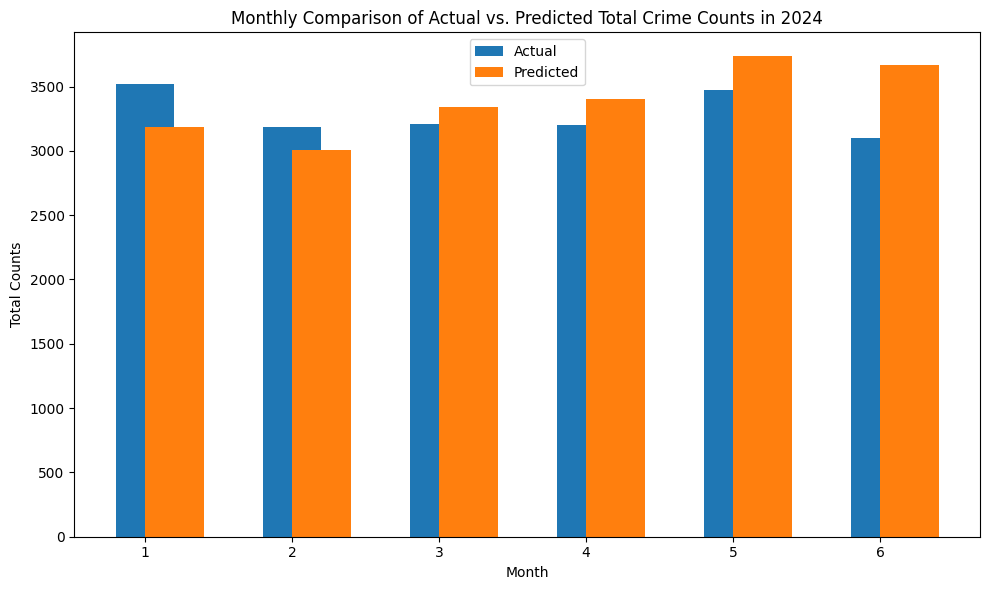

### Visualizations based on the Predictions

back to the top

```
array([1, 2, 3, 4, 5, 6])
```

back to the top

|  | NEIGHBOURHOOD_158 | HOOD_158 | OCC_YEAR | OCC_MONTH |
| --- | --- | --- | --- | --- |
| 0 | West Humber-Clairville (1) | 1 | 2024 | 7 |
| 1 | West Humber-Clairville (1) | 1 | 2024 | 8 |
| 2 | West Humber-Clairville (1) | 1 | 2024 | 9 |
| 3 | West Humber-Clairville (1) | 1 | 2024 | 10 |
| 4 | West Humber-Clairville (1) | 1 | 2024 | 11 |
| ... | ... | ... | ... | ... |
| 6630 | South Eglinton-Davisville (174) | 174 | 2027 | 8 |
| 6631 | South Eglinton-Davisville (174) | 174 | 2027 | 9 |
| 6632 | South Eglinton-Davisville (174) | 174 | 2027 | 10 |
| 6633 | South Eglinton-Davisville (174) | 174 | 2027 | 11 |
| 6634 | South Eglinton-Davisville (174) | 174 | 2027 | 12 |

6635 rows × 4 columns

back to the top

|  | NEIGHBOURHOOD_158 | HOOD_158 | OCC_YEAR | OCC_MONTH | Total_Counts |
| --- | --- | --- | --- | --- | --- |
| 0 | West Humber-Clairville (1) | 1 | 2024 | 7 | 111 |
| 1 | West Humber-Clairville (1) | 1 | 2024 | 8 | 111 |
| 2 | West Humber-Clairville (1) | 1 | 2024 | 9 | 108 |
| 3 | West Humber-Clairville (1) | 1 | 2024 | 10 | 110 |
| 4 | West Humber-Clairville (1) | 1 | 2024 | 11 | 107 |
| ... | ... | ... | ... | ... | ... |
| 6630 | South Eglinton-Davisville (174) | 174 | 2027 | 8 | 12 |
| 6631 | South Eglinton-Davisville (174) | 174 | 2027 | 9 | 12 |
| 6632 | South Eglinton-Davisville (174) | 174 | 2027 | 10 | 14 |
| 6633 | South Eglinton-Davisville (174) | 174 | 2027 | 11 | 14 |
| 6634 | South Eglinton-Davisville (174) | 174 | 2027 | 12 | 15 |

6635 rows × 5 columns

#### Anticipated Crime Statistics for next six months of 2024

back to the top

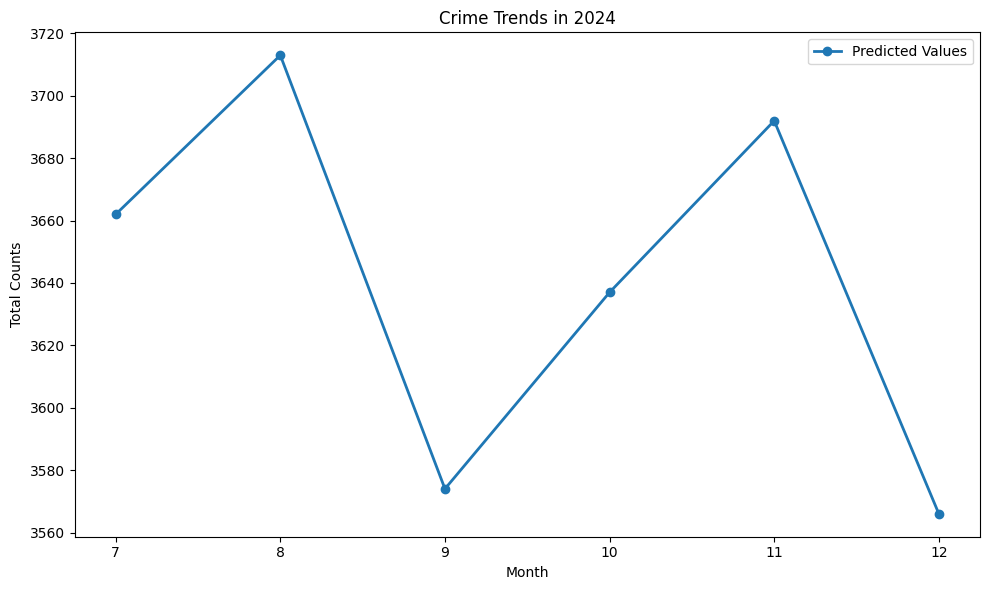

#### Anticipated Total count of Crime Acitivities for upcoming three years

back to the top

|  | OCC_YEAR | Total_Counts |
| --- | --- | --- |
| 0 | 2025 | 42192 |
| 1 | 2026 | 42192 |
| 2 | 2027 | 42184 |

back to the top

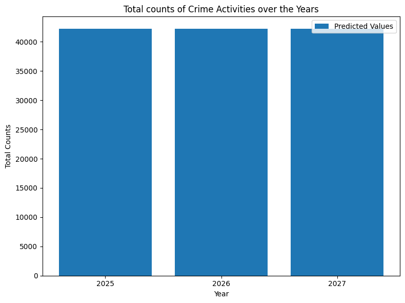

back to the top

|  | OCC_YEAR | OCC_MONTH | Total_Counts |
| --- | --- | --- | --- |
| 0 | 2025 | 1 | 3187 |
| 1 | 2025 | 2 | 3007 |
| 2 | 2025 | 3 | 3342 |
| 3 | 2025 | 4 | 3407 |
| 4 | 2025 | 5 | 3735 |

back to the top

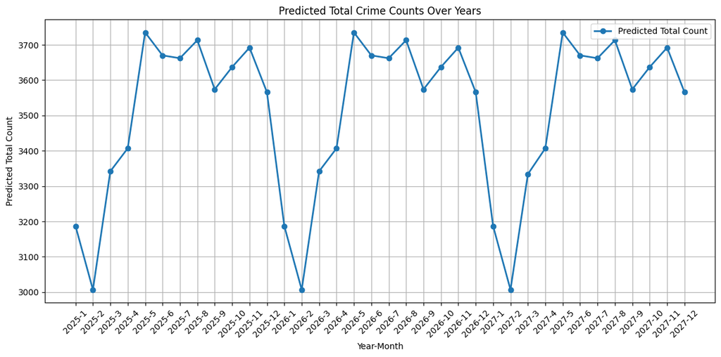

#### Anticipated Crime Statistics for 2025

back to the top

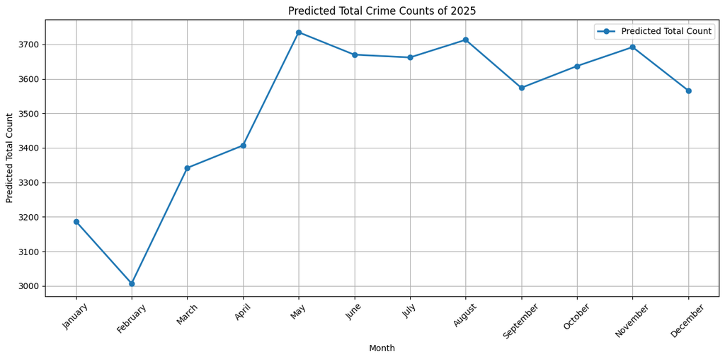

#### Anticipated Crime Statistics for 2026

back to the top

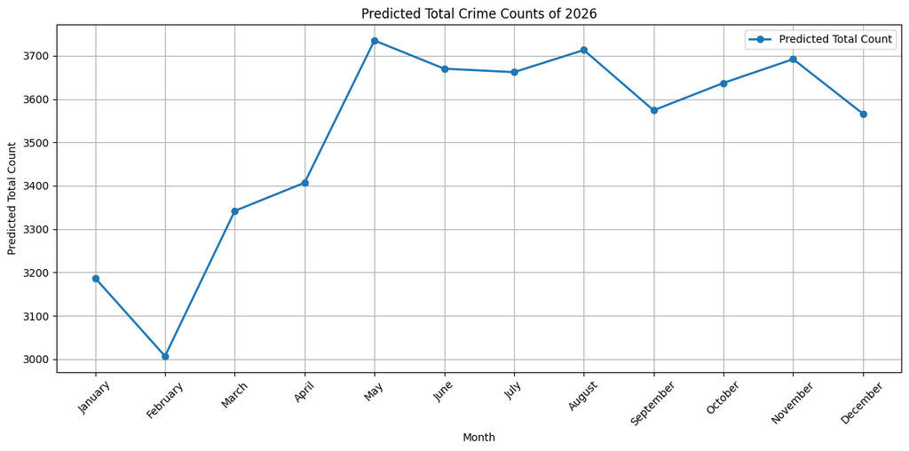

#### Anticipated Crime Statistics for 2027

back to the top

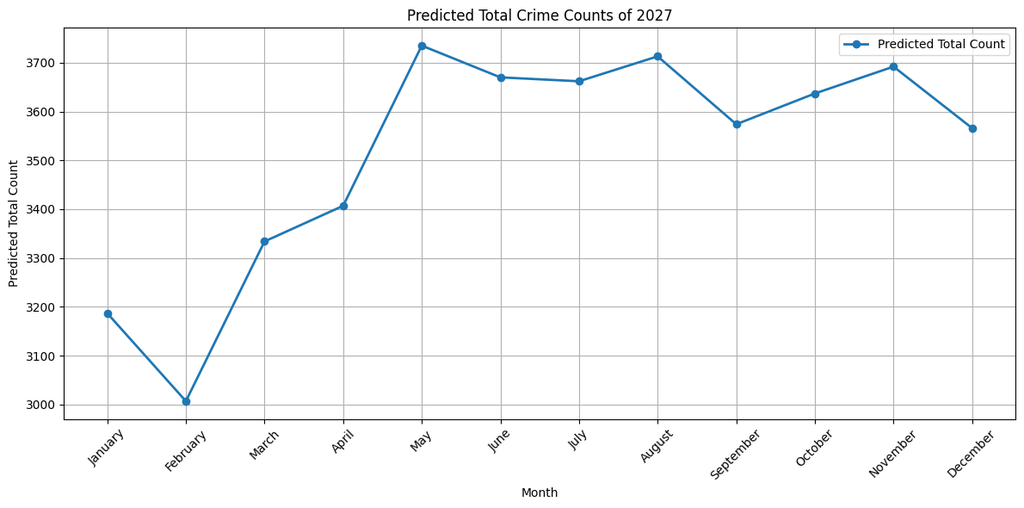